# Personal Communal Orientation

### [Home](https://pbischoff3.github.io/Projects/BIOL_3100) | [Data Overview](https://pbischoff3.github.io/Projects/BIOL_3100/data_overview/) | [Multi-Dimensional Analysis](https://pbischoff3.github.io/Projects/BIOL_3100/multi_dimensional_analysis/) | [Models](https://pbischoff3.github.io/Projects/BIOL_3100/models/) | [Conclusion](https://pbischoff3.github.io/Projects/BIOL_3100/Conclusion/)

#### [Science Identity](https://pbischoff3.github.io/Projects/BIOL_3100/models/si/) | [Career Motivation](https://pbischoff3.github.io/Projects/BIOL_3100/models/cm/) | [Intrinsic Motivation](https://pbischoff3.github.io/Projects/BIOL_3100/models/im/) | [Self-Determination](https://pbischoff3.github.io/Projects/BIOL_3100/models/sd/) | [Self-Efficacy](https://pbischoff3.github.io/Projects/BIOL_3100/models/se/) | [Grade Motivation](https://pbischoff3.github.io/Projects/BIOL_3100/models/gm) | [Personal Communal Orientation](https://pbischoff3.github.io/Projects/BIOL_3100/models/per_com_orient/) | [Analysis](https://pbischoff3.github.io/Projects/BIOL_3100/models/analysis/)

Let’s check out Personal Communal Orientation models.

## Major

Let’s see the influence that the difference in majors have an the average of Personal Communal Orientation questions:

```
##
## Call:
## glm(formula = persol_comm_orient_ave ~ major, data = df)
##
## Deviance Residuals:
##     Min       1Q   Median       3Q      Max
## -5.4756  -0.4756   0.0244   0.5244   1.5667
##
## Coefficients:
##                   Estimate Std. Error t value Pr(>|t|)
## (Intercept)        5.28873    0.09355  56.533   <2e-16 ***
## majorChemistry    -0.28873    0.31228  -0.925   0.3559
## majorComputer_sci -0.28873    0.31228  -0.925   0.3559
## majorEarth_sci    -1.28873    0.79381  -1.623   0.1055
## majorEngineering  -0.10540    0.22400  -0.471   0.6383
## majorHealth_sci    0.18692    0.11308   1.653   0.0994 .
## majorMathematics   0.46127    0.56519   0.816   0.4151
## majorNon_STEM      0.33083    0.18913   1.749   0.0813 .
## majorOther         0.21908    0.16784   1.305   0.1928
## ---
## Signif. codes:  0 '***' 0.001 '**' 0.01 '*' 0.05 '.' 0.1 ' ' 1
##
## (Dispersion parameter for gaussian family taken to be 0.6213853)
##
##     Null deviance: 196.65  on 311  degrees of freedom
## Residual deviance: 188.28  on 303  degrees of freedom
## AIC: 747.83
##
## Number of Fisher Scoring iterations: 2
```

This shows that difference in Majors may not have an influence on Personal Communal Orientation.

This is great, but it is difficult to understand this in context until we compare it to the other models.

## Career

Now, let’s look at how career goals affect the average of Personal Communal Orientation questions:

```
##
## Call:
## glm(formula = persol_comm_orient_ave ~ career, data = df)
##
## Deviance Residuals:
##     Min       1Q   Median       3Q      Max
## -5.4688  -0.4221   0.0779   0.5312   1.5944
##
## Coefficients:
##                       Estimate Std. Error t value Pr(>|t|)
## (Intercept)            5.40556    0.11356  47.599  < 2e-16 ***
## careereducator         0.65214    0.23988   2.719 0.006933 **
## careerengineer        -0.12222    0.22713  -0.538 0.590891
## careerhealth_care_pro  0.01658    0.13287   0.125 0.900803
## careermedical_doctor   0.06319    0.14477   0.437 0.662767
## careernon_stem         0.21944    0.20473   1.072 0.284634
## careerresearcher      -1.19127    0.30953  -3.849 0.000145 ***
## careerscientist       -0.46806    0.24751  -1.891 0.059569 .
## careertechnician      -0.44722    0.33110  -1.351 0.177788
## ---
## Signif. codes:  0 '***' 0.001 '**' 0.01 '*' 0.05 '.' 0.1 ' ' 1
##
## (Dispersion parameter for gaussian family taken to be 0.5803627)
##
##     Null deviance: 196.65  on 311  degrees of freedom
## Residual deviance: 175.85  on 303  degrees of freedom
## AIC: 726.53
##
## Number of Fisher Scoring iterations: 2
```

This shows that Educators have significantly higher Personal Communal Orientation and Researchers have significantly lower Personal Communal Orientation.

Now let’s run from another model’s point of view.

## Ethnicity

How about we look at how different ethnicities affect Personal Communal Orientation?

```
##
## Call:
## glm(formula = persol_comm_orient_ave ~ ethnicity, data = df)
##
## Deviance Residuals:
##     Min       1Q   Median       3Q      Max
## -4.7500  -0.4151   0.0849   0.5849   1.5849
##
## Coefficients:
##                            Estimate Std. Error t value Pr(>|t|)
## (Intercept)                  4.7500     0.3549  13.385   <2e-16 ***
## ethnicityamerican_indian     1.0000     0.5323   1.879   0.0613 .
## ethnicityarab                1.2500     0.8693   1.438   0.1515
## ethnicityasian               0.2500     0.4426   0.565   0.5726
## ethnicitybiracial            1.0833     0.4426   2.448   0.0150 *
## ethnicitylatinx              0.6912     0.4037   1.712   0.0879 .
## ethnicityother               0.7500     0.8693   0.863   0.3889
## ethnicitypacific_islander    0.6667     0.5795   1.150   0.2509
## ethnicityprefer_not_answer   0.3750     0.5323   0.704   0.4817
## ethnicitywhite               0.6651     0.3583   1.856   0.0644 .
## ---
## Signif. codes:  0 '***' 0.001 '**' 0.01 '*' 0.05 '.' 0.1 ' ' 1
##
## (Dispersion parameter for gaussian family taken to be 0.6297239)
##
##     Null deviance: 196.65  on 311  degrees of freedom
## Residual deviance: 190.18  on 302  degrees of freedom
## AIC: 752.96
##
## Number of Fisher Scoring iterations: 2
```

This shows that those who are Biracial have significantly higher Personal Communal Orientation.

One last model. Let’s check it out.

## Medical Conditions

Here is the model according to a presence of medical conditions or not.

```
##
## Call:
## glm(formula = persol_comm_orient_ave ~ med_condition, data = df)
##
## Deviance Residuals:
##     Min       1Q   Median       3Q      Max
## -5.3974  -0.3974   0.1026   0.6026   1.6026
##
## Coefficients:
##                  Estimate Std. Error t value Pr(>|t|)
## (Intercept)       5.39744    0.04817 112.050   <2e-16 ***
## med_conditionYes  0.08974    0.13625   0.659    0.511
## ---
## Signif. codes:  0 '***' 0.001 '**' 0.01 '*' 0.05 '.' 0.1 ' ' 1
##
## (Dispersion parameter for gaussian family taken to be 0.6334574)
##
##     Null deviance: 196.65  on 311  degrees of freedom
## Residual deviance: 196.37  on 310  degrees of freedom
## AIC: 746.96
##
## Number of Fisher Scoring iterations: 2
```

This shows that Medical Conditions does not have an influence on Personal Communal Orientation.

## Conclusion

Now that we have those 4 models according to the demographic that we are interested in, let’s compare them against each other to see which models were best in determining Personal Communal Orientation.

```
## Parameter                     |      pco_mod_1 |       pco_mod_2 |      pco_mod_3 |      pco_mod_4
## --------------------------------------------------------------------------------------------------
## (Intercept)                   | 5.29*** (0.09) |  5.41*** (0.11) | 4.75*** (0.35) | 5.40*** (0.05)
## major (Computer_sci)          |   -0.29 (0.31) |                 |                |
## major (Earth_sci)             |   -1.29 (0.79) |                 |                |
## major (Engineering)           |   -0.11 (0.22) |                 |                |
## major (Chemistry)             |   -0.29 (0.31) |                 |                |
## major (Mathematics)           |    0.46 (0.57) |                 |                |
## major (Non_STEM)              |    0.33 (0.19) |                 |                |
## major (Other)                 |    0.22 (0.17) |                 |                |
## major (Health_sci)            |    0.19 (0.11) |                 |                |
## career (engineer)             |                |    -0.12 (0.23) |                |
## career (health_care_pro)      |                |     0.02 (0.13) |                |
## career (medical_doctor)       |                |     0.06 (0.14) |                |
## career (educator)             |                |   0.65** (0.24) |                |
## career (researcher)           |                | -1.19*** (0.31) |                |
## career (scientist)            |                |    -0.47 (0.25) |                |
## career (technician)           |                |    -0.45 (0.33) |                |
## career (non_stem)             |                |     0.22 (0.20) |                |
## ethnicity (asian)             |                |                 |    0.25 (0.44) |
## ethnicity (biracial)          |                |                 |   1.08* (0.44) |
## ethnicity (american_indian)   |                |                 |    1.00 (0.53) |
## ethnicity (arab)              |                |                 |    1.25 (0.87) |
## ethnicity (pacific_islander)  |                |                 |    0.67 (0.58) |
## ethnicity (prefer_not_answer) |                |                 |    0.37 (0.53) |
## ethnicity (latinx)            |                |                 |    0.69 (0.40) |
## ethnicity (other)             |                |                 |    0.75 (0.87) |
## ethnicity (white)             |                |                 |    0.67 (0.36) |
## med condition (Yes)           |                |                 |                |    0.09 (0.14)
## --------------------------------------------------------------------------------------------------
## Observations                  |            312 |             312 |            312 |            312
```

This shows everything that we have performed thus far, but now let’s add some statistical analysis to it.

```
## # Comparison of Model Performance Indices
##
## Name      | Model |     AIC | AIC weights |     BIC | BIC weights |    R2 |  RMSE | Sigma
## -----------------------------------------------------------------------------------------
## pco_mod_1 |   glm | 747.834 |    2.36e-05 | 785.264 |    1.25e-06 | 0.043 | 0.777 | 0.788
## pco_mod_2 |   glm | 726.525 |       1.000 | 763.955 |       0.053 | 0.106 | 0.751 | 0.762
## pco_mod_3 |   glm | 752.962 |    1.82e-06 | 794.135 |    1.48e-08 | 0.033 | 0.781 | 0.794
## pco_mod_4 |   glm | 746.964 |    3.65e-05 | 758.193 |       0.947 | 0.001 | 0.793 | 0.796
```

```
##
## Call:
## glm(formula = persol_comm_orient_ave ~ ethnicity + major + med_condition,
##     data = df)
##
## Deviance Residuals:
##     Min       1Q   Median       3Q      Max
## -4.7849  -0.4767   0.0233   0.5000   1.5634
##
## Coefficients:
##                            Estimate Std. Error t value Pr(>|t|)
## (Intercept)                 4.56648    0.36275  12.589  < 2e-16 ***
## ethnicityamerican_indian    0.93499    0.53330   1.753  0.08061 .
## ethnicityarab               1.43352    0.86529   1.657  0.09865 .
## ethnicityasian              0.36619    0.44660   0.820  0.41292
## ethnicitybiracial           1.24995    0.44797   2.790  0.00561 **
## ethnicitylatinx             0.70961    0.40172   1.766  0.07836 .
## ethnicityother              0.93352    0.86529   1.079  0.28154
## ethnicitypacific_islander   0.61170    0.57718   1.060  0.29010
## ethnicityprefer_not_answer  0.43425    0.52978   0.820  0.41306
## ethnicitywhite              0.69185    0.35580   1.944  0.05279 .
## majorChemistry             -0.34197    0.32838  -1.041  0.29856
## majorComputer_sci          -0.25833    0.31271  -0.826  0.40942
## majorEarth_sci             -1.25833    0.79169  -1.589  0.11304
## majorEngineering           -0.07174    0.22695  -0.316  0.75216
## majorHealth_sci             0.21838    0.11543   1.892  0.05950 .
## majorMathematics            0.49167    0.56409   0.872  0.38413
## majorNon_STEM               0.36753    0.19073   1.927  0.05496 .
## majorOther                  0.26245    0.16950   1.548  0.12260
## med_conditionYes            0.06030    0.13911   0.433  0.66499
## ---
## Signif. codes:  0 '***' 0.001 '**' 0.01 '*' 0.05 '.' 0.1 ' ' 1
##
## (Dispersion parameter for gaussian family taken to be 0.6171441)
##
##     Null deviance: 196.65  on 311  degrees of freedom
## Residual deviance: 180.82  on 293  degrees of freedom
## AIC: 755.23
##
## Number of Fisher Scoring iterations: 2
```

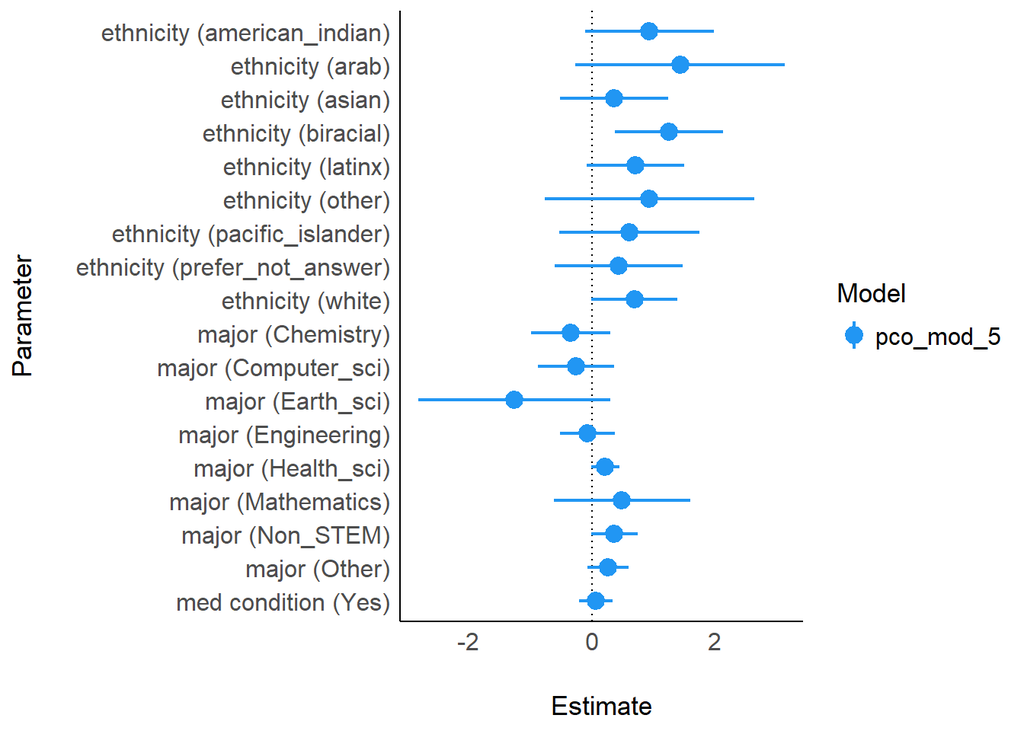

Well awesome, this gives us a great place that we can start in further data analysis in our project.

[figure not shown]

### [**NEXT**](https://pbischoff3.github.io/Projects/BIOL_3100/models/analysis/)